# Prediction Assignment Writeup

Francisco J. Guzman

3/18/2021

## 1. Synopsis

Using devices such as Jawbone Up, Nike FuelBand, and Fitbit it is now possible to collect a large amount of data about personal activity relatively inexpensively. In this project, we use data from accelerometers on the belt, forearm, arm, and dumbell of 6 participants. They were asked to perform barbell lifts correctly and incorrectly in 5 different ways.

We aim to predict the manner in which the participants performed the exercise, which is stored in the “classe” variable in the training set. We will try to predict the classe value (A, B, C, D, or E) for the 20 test cases and submit it in the quizz.

## 2. Data Loading, Clean-up and Partition

### 2.1 Data Loading and Clean-up

The datasets have 160 variables. The first task is to clean NAs, Near Zero variance (NZV) variables and the first columns (used for identification only).

```
## [1] 19622    54
```

```
## [1] 20 54
```

### 2.2. Data Partitioning

As per recommendation of the course __ Practical Machine Learning__ , we will be seggregating our org_training_data into 2 different parts, one is the training set (consisiting 70% of the total data) and test set (consisting 30% of the total data)

```
## [1] 13737    54
```

```
## [1] 5885   54
```

## 3. Correlation Analysis

A correlation among variables is analysed before proceeding to the modeling procedures.

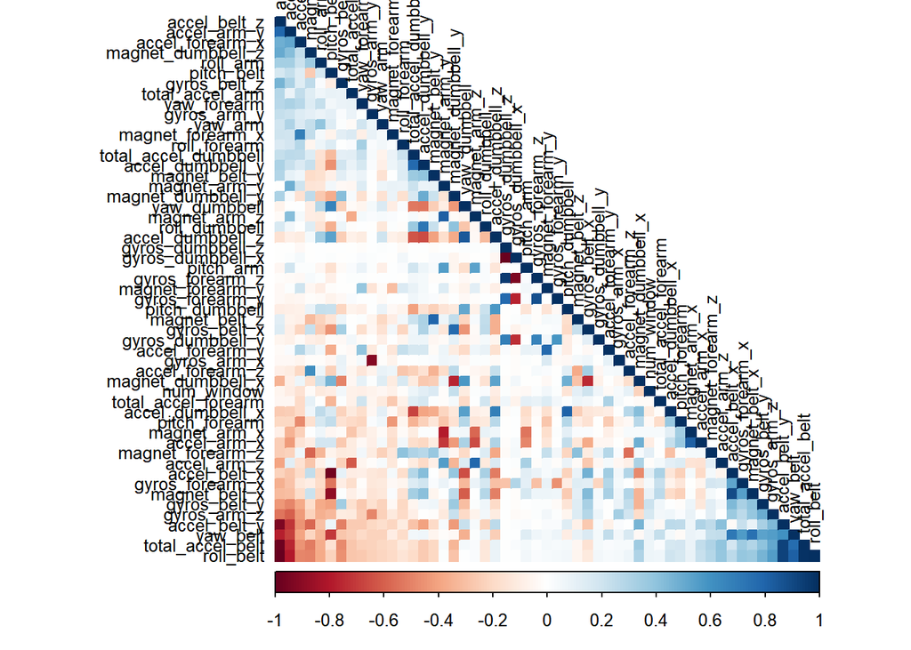

The graph above shows highly correlated variables in dark colors which are quite disperse so PCA (Principal Components Analysis) is not considered required as a pre-processing step to the datasets.

## 4. Prediction Model Building

Three methods will be applied to model the regressions (in the Train dataset) and the best one (with higher accuracy when applied to the Test dataset) will be used for the quiz predictions. The methods are: Random Forests, Decision Tree and Generalized Boosted Model, as described below. A Confusion Matrix is plotted at the end of each analysis to better visualize the accuracy of the models.

### 4.1. Method 1: Random Forest

```
##
## Call:
##  randomForest(x = x, y = y, mtry = param$mtry)
##                Type of random forest: classification
##                      Number of trees: 500
## No. of variables tried at each split: 27
##
##         OOB estimate of  error rate: 0.28%
## Confusion matrix:
##      A    B    C    D    E  class.error
## A 3904    1    0    0    1 0.0005120328
## B    9 2643    5    1    0 0.0056433409
## C    0    6 2390    0    0 0.0025041736
## D    0    0    7 2244    1 0.0035523979
## E    0    1    0    6 2518 0.0027722772
```

```
## Confusion Matrix and Statistics
##
##           Reference
## Prediction    A    B    C    D    E
##          A 1674    5    0    0    0
##          B    0 1134    0    0    0
##          C    0    0 1026    0    0
##          D    0    0    0  964    3
##          E    0    0    0    0 1079
##
## Overall Statistics
##
##                Accuracy : 0.9986
##                  95% CI : (0.9973, 0.9994)
##     No Information Rate : 0.2845
##     P-Value [Acc > NIR] : < 2.2e-16
##
##                   Kappa : 0.9983
##
##  Mcnemar's Test P-Value : NA
##
## Statistics by Class:
##
##                      Class: A Class: B Class: C Class: D Class: E
## Sensitivity            1.0000   0.9956   1.0000   1.0000   0.9972
## Specificity            0.9988   1.0000   1.0000   0.9994   1.0000
## Pos Pred Value         0.9970   1.0000   1.0000   0.9969   1.0000
## Neg Pred Value         1.0000   0.9989   1.0000   1.0000   0.9994
## Prevalence             0.2845   0.1935   0.1743   0.1638   0.1839
## Detection Rate         0.2845   0.1927   0.1743   0.1638   0.1833
## Detection Prevalence   0.2853   0.1927   0.1743   0.1643   0.1833
## Balanced Accuracy      0.9994   0.9978   1.0000   0.9997   0.9986
```

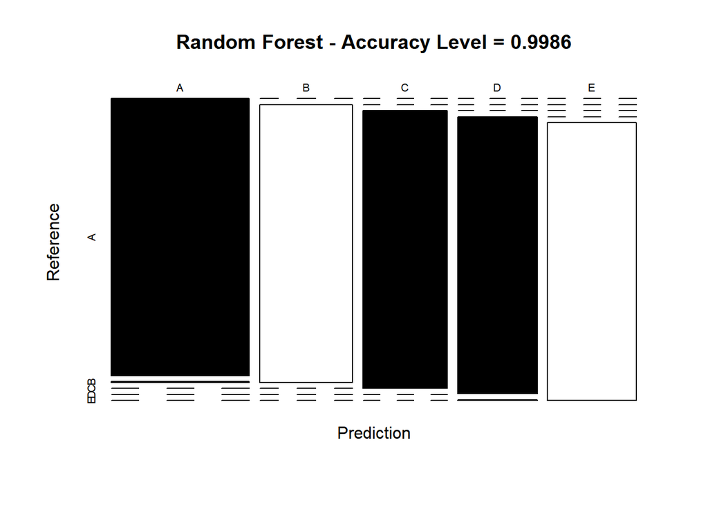

### 4.2. Method 2: Decision Trees

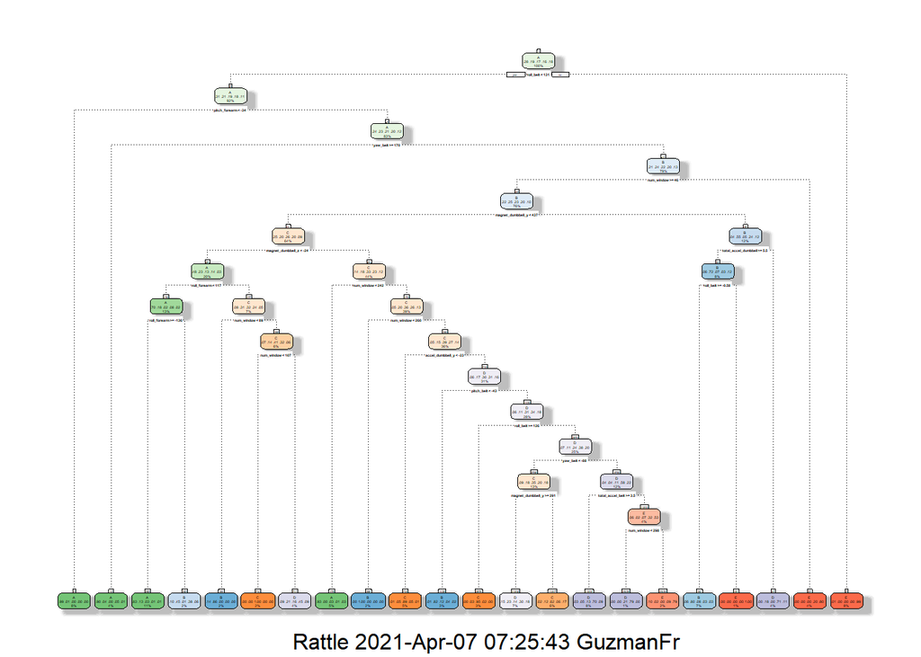

```
## Confusion Matrix and Statistics
##
##           Reference
## Prediction    A    B    C    D    E
##          A 1481  125   26   27   10
##          B   70  762   37   65   32
##          C    6   62  808   36   62
##          D  101  185  155  775  159
##          E   16    5    0   61  819
##
## Overall Statistics
##
##                Accuracy : 0.7893
##                  95% CI : (0.7786, 0.7997)
##     No Information Rate : 0.2845
##     P-Value [Acc > NIR] : < 2.2e-16
##
##                   Kappa : 0.7341
##
##  Mcnemar's Test P-Value : < 2.2e-16
##
## Statistics by Class:
##
##                      Class: A Class: B Class: C Class: D Class: E
## Sensitivity            0.8847   0.6690   0.7875   0.8039   0.7569
## Specificity            0.9554   0.9570   0.9658   0.8781   0.9829
## Pos Pred Value         0.8874   0.7888   0.8296   0.5636   0.9090
## Neg Pred Value         0.9542   0.9234   0.9556   0.9581   0.9472
## Prevalence             0.2845   0.1935   0.1743   0.1638   0.1839
## Detection Rate         0.2517   0.1295   0.1373   0.1317   0.1392
## Detection Prevalence   0.2836   0.1641   0.1655   0.2336   0.1531
## Balanced Accuracy      0.9200   0.8130   0.8767   0.8410   0.8699
```

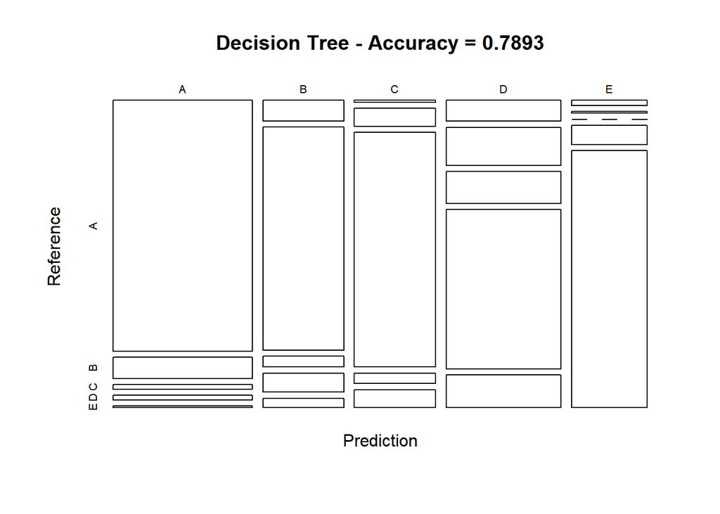

### 4.3. Method 3: Generalized Boosted Model

```
## A gradient boosted model with multinomial loss function.
## 150 iterations were performed.
## There were 53 predictors of which 53 had non-zero influence.
```

```
## Confusion Matrix and Statistics
##
##
## predictGBM    A    B    C    D    E
##          A 1674   16    0    0    0
##          B    0 1113    3    6    4
##          C    0    8 1020    3    1
##          D    0    2    2  954   13
##          E    0    0    1    1 1064
##
## Overall Statistics
##
##                Accuracy : 0.9898
##                  95% CI : (0.9869, 0.9922)
##     No Information Rate : 0.2845
##     P-Value [Acc > NIR] : < 2.2e-16
##
##                   Kappa : 0.9871
##
##  Mcnemar's Test P-Value : NA
##
## Statistics by Class:
##
##                      Class: A Class: B Class: C Class: D Class: E
## Sensitivity            1.0000   0.9772   0.9942   0.9896   0.9834
## Specificity            0.9962   0.9973   0.9975   0.9965   0.9996
## Pos Pred Value         0.9905   0.9885   0.9884   0.9825   0.9981
## Neg Pred Value         1.0000   0.9945   0.9988   0.9980   0.9963
## Prevalence             0.2845   0.1935   0.1743   0.1638   0.1839
## Detection Rate         0.2845   0.1891   0.1733   0.1621   0.1808
## Detection Prevalence   0.2872   0.1913   0.1754   0.1650   0.1811
## Balanced Accuracy      0.9981   0.9872   0.9958   0.9931   0.9915
```

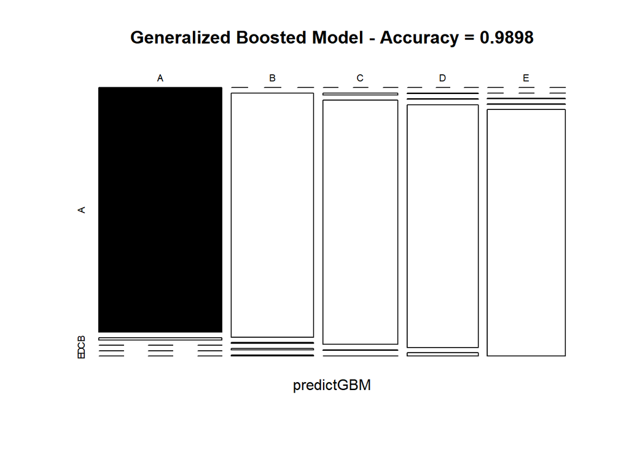

## 5. Predictions using best accuracy model

As shown, best accuracy model was Random Forest, so prediction execution with Test Data

```
## Predictions:  B A B A A E D B A A B C B A E E A B B B
```